# NYPD Shooting Incident Data Analysis

Y

2025-07-25

## Background

This dataset provides a comprehensive overview of every shooting incident that has taken place in New York City from 2013 through the end of the previous calendar year. The data is manually extracted on a quarterly basis and reviewed by the Office of Management Analysis and Planning before being published on the NYPD website. Each entry details a shooting incident, including information about the event, its location, and the time it occurred. Additionally, the dataset includes demographic information about both suspects and victims. This data serves as a valuable resource for the public to examine the patterns and nature of police enforcement activities.

A summary of the descriptive data can be found as below.

- **INCIDENT_KEY**: Randomly generated persistent ID for each incident
- **OCCUR_DATE**: Exact date of the shooting incident
- **OCCUR_TIME**: Exact time of the shooting incident
- **BORO**: Borough where the shooting incident occurred
- **PRECINCT**: Precinct where the shooting incident occurred
- **JURISDICTION_CODE**: Jurisdiction where the shooting incident occurred. Jurisdiction codes 0(Patrol), 1(Transit), and 2(Housing) represent NYPD, while codes 3 and more represent non-NYPD jurisdictions
- **LOCATION_DESC**: Location of the shooting incident
- **STATISTICAL_MURDER_FLAG**: Shooting resulted in the victim’s death which would be counted as a murder
- **PERP_AGE_GROUP**: Perpetrator’s age within a category
- **PERP_SEX**: Perpetrator’s sex description
- **PERP_RACE**: Perpetrator’s race description
- **VIC_AGE_GROUP**: Victim’s age within a category
- **VIC_SEX**: Victim’s sex description
- **VIC_RACE**: Victim’s race description
- **X_COORD_CD**: Midblock X-coordinate for New York State Plane Coordinate System, Long Island Zone, NAD 83, units feet (FIPS 3104)
- **Y_COORD_CD**: Midblock Y-coordinate for New York State Plane Coordinate System, Long Island Zone, NAD 83, units feet (FIPS 3104)

## Import the required packages

```r
library(tidyverse)
```

```r
library(lubridate)
library(ggplot2)
library(gridExtra)
```

## Load the data

```r
df = read_csv("https://data.cityofnewyork.us/api/views/833y-fsy8/rows.csv?accessType=DOWNLOAD")
```

## Data Preparation

To simplify the dataset and improve focus on the most important features, the following unnecessary columns were be eliminated: LOC_CLASSFCTN_DESC, LOCATION_DESC, X_COORD_CD, Y_COORD_CD, Lon_Lat

```r
df_2 = df %>% select(INCIDENT_KEY,
                   OCCUR_DATE,
                   OCCUR_TIME,
                   BORO,
                   LOC_OF_OCCUR_DESC,
                   PRECINCT,
                   JURISDICTION_CODE,
                   STATISTICAL_MURDER_FLAG,
                   PERP_AGE_GROUP,
                   PERP_SEX,
                   PERP_RACE,
                   VIC_AGE_GROUP,
                   VIC_SEX,
                   VIC_RACE,
                   Latitude,
                   Longitude)
```

### Handling Missing Values

```r
# Return the column name along with the missing values
lapply(df_2, function(x) sum(is.na(x)))
```

```
## $INCIDENT_KEY
## [1] 0
##
## $OCCUR_DATE
## [1] 0
##
## $OCCUR_TIME
## [1] 0
##
## $BORO
## [1] 0
##
## $LOC_OF_OCCUR_DESC
## [1] 25596
##
## $PRECINCT
## [1] 0
##
## $JURISDICTION_CODE
## [1] 2
##
## $STATISTICAL_MURDER_FLAG
## [1] 0
##
## $PERP_AGE_GROUP
## [1] 9344
##
## $PERP_SEX
## [1] 9310
##
## $PERP_RACE
## [1] 9310
##
## $VIC_AGE_GROUP
## [1] 0
##
## $VIC_SEX
## [1] 0
##
## $VIC_RACE
## [1] 0
##
## $Latitude
## [1] 97
##
## $Longitude
## [1] 97
```

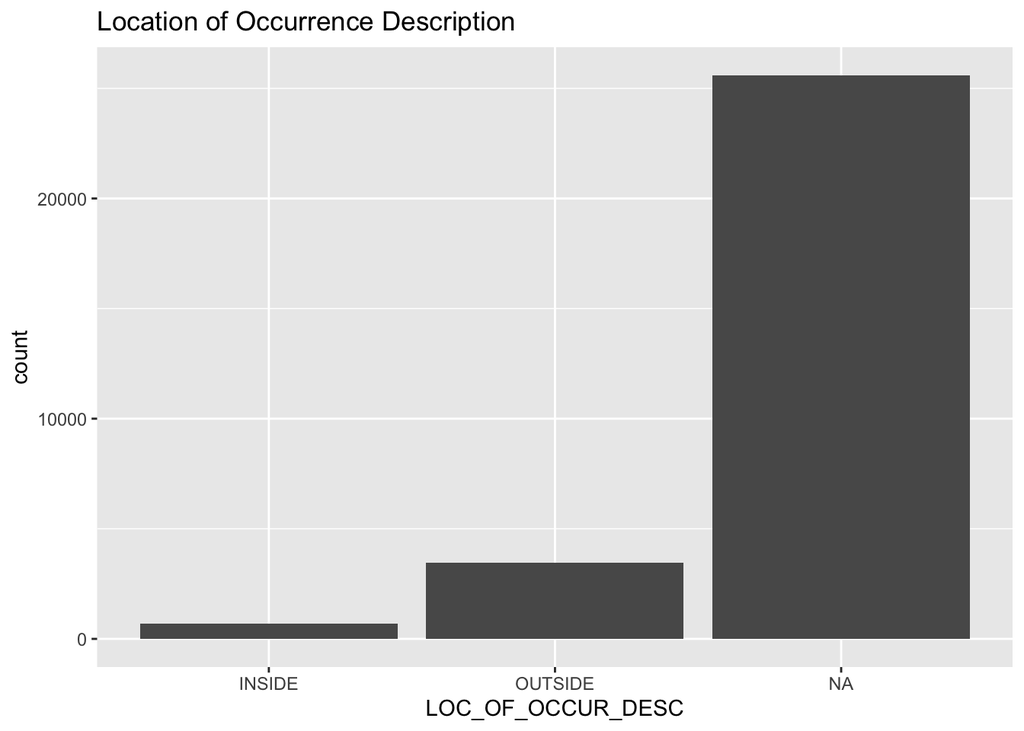

```r
# Plot the distribution of variables with missing values


# Plot 1: LOC_OF_OCCUR_DESC
plot1 <- ggplot(df, aes(x = LOC_OF_OCCUR_DESC)) +
  geom_bar() +
  ggtitle("Location of Occurrence Description")

# Plot 2: JURISDICTION_CODE
plot2 <- ggplot(df, aes(x = JURISDICTION_CODE)) +
  geom_bar() +
  ggtitle("Jurisdiction Code")

# Plot 3: PERP_AGE_GROUP
plot3 <- ggplot(df, aes(x = PERP_AGE_GROUP)) +
  geom_bar() +
  ggtitle("Perpetrator Age Group")

# Plot 4: PERP_SEX
plot4 <- ggplot(df, aes(x = PERP_SEX)) +
  geom_bar() +
  ggtitle("Perpetrator Sex")

# Plot 5: PERP_RACE
plot5 <- ggplot(df, aes(x = PERP_RACE)) +
  geom_bar() +
  ggtitle("Perpetrator Race")

# Display each plot one by one
print(plot1)
```

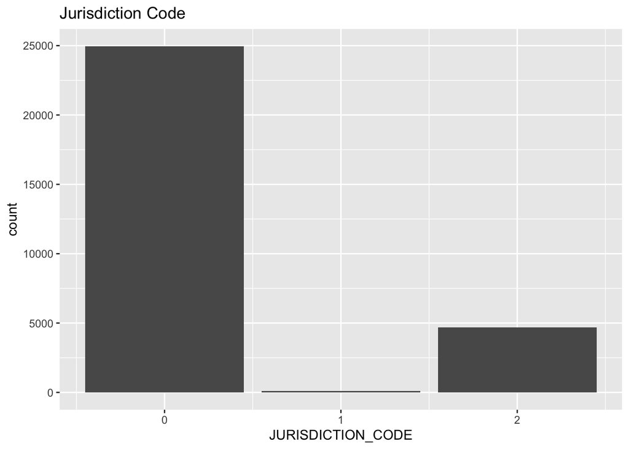

```r
print(plot2)
```

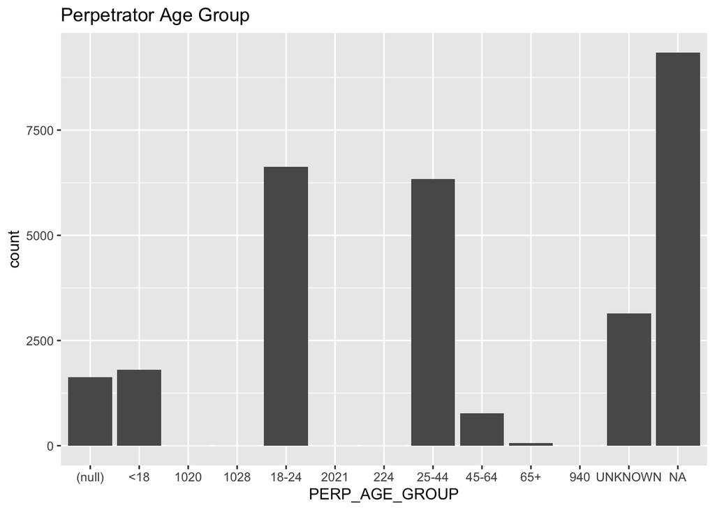

```r
print(plot3)
```

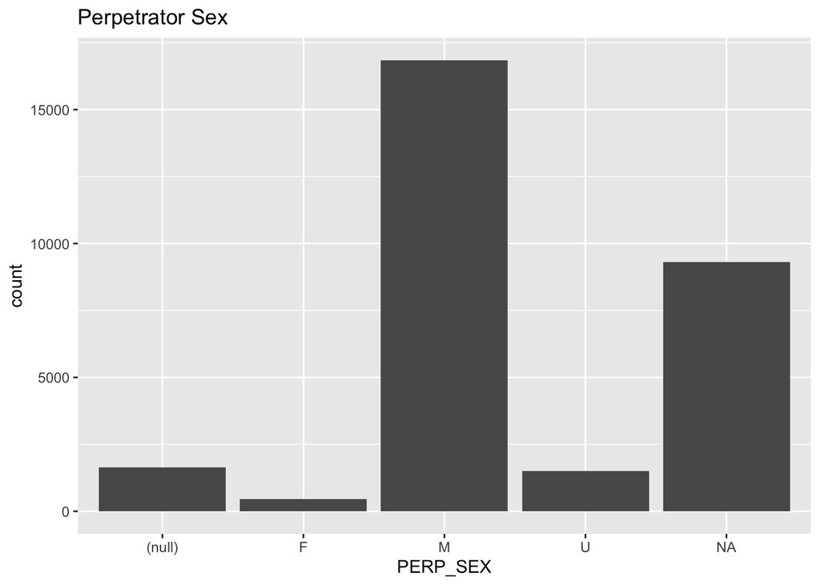

```r
print(plot4)
```

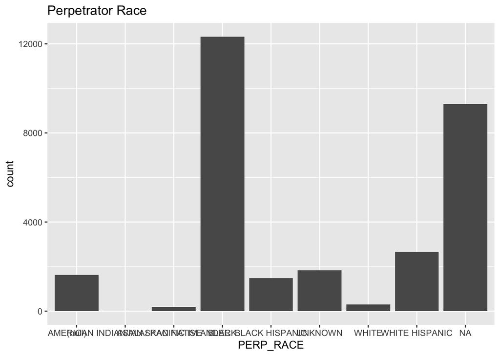

```r
print(plot5)
```

```r
summary(df_2)
```

```
##   INCIDENT_KEY        OCCUR_DATE         OCCUR_TIME           BORO
##  Min.   :  9953245   Length:29744       Length:29744      Length:29744
##  1st Qu.: 67321140   Class :character   Class1:hms        Class :character
##  Median :109291972   Mode  :character   Class2:difftime   Mode  :character
##  Mean   :133850951                      Mode  :numeric
##  3rd Qu.:214741917
##  Max.   :299462478
##
##  LOC_OF_OCCUR_DESC     PRECINCT      JURISDICTION_CODE STATISTICAL_MURDER_FLAG
##  Length:29744       Min.   :  1.00   Min.   :0.0000    Mode :logical
##  Class :character   1st Qu.: 44.00   1st Qu.:0.0000    FALSE:23979
##  Mode  :character   Median : 67.00   Median :0.0000    TRUE :5765
##                     Mean   : 65.23   Mean   :0.3181
##                     3rd Qu.: 81.00   3rd Qu.:0.0000
##                     Max.   :123.00   Max.   :2.0000
##                                      NA's   :2
##  PERP_AGE_GROUP       PERP_SEX          PERP_RACE         VIC_AGE_GROUP
##  Length:29744       Length:29744       Length:29744       Length:29744
##  Class :character   Class :character   Class :character   Class :character
##  Mode  :character   Mode  :character   Mode  :character   Mode  :character
##
##
##
##
##    VIC_SEX            VIC_RACE            Latitude       Longitude
##  Length:29744       Length:29744       Min.   :40.51   Min.   :-74.25
##  Class :character   Class :character   1st Qu.:40.67   1st Qu.:-73.94
##  Mode  :character   Mode  :character   Median :40.70   Median :-73.91
##                                        Mean   :40.74   Mean   :-73.91
##                                        3rd Qu.:40.83   3rd Qu.:-73.88
##                                        Max.   :40.91   Max.   :-73.70
##                                        NA's   :97      NA's   :97
```

There are noticeble missing values for LOC_OF_OCCUR_DESC, PERP_AGE_GROUP, PERP_SEX and PERP_RACE, those cases are possibly still active and ongoing investigation. In fear of missing meaningful information, I handle this group of missing data by calling them as another group of “UNKNOWN”. Since the number NAs in JURISDICTION_CODE, Latitude and Longitude are relatively small, those rows with NA were filtered out.

```r
# Deal with missing values
# Deal with missing values and '(null)' entries
df_2 <- df_2 %>%
  mutate(across(c(LOC_OF_OCCUR_DESC, PERP_AGE_GROUP, PERP_SEX, PERP_RACE),
                ~ replace_na(ifelse(. == "(null)", "UNKNOWN", .), "UNKNOWN")))




df_3 <- df_2 %>%
  filter(complete.cases(JURISDICTION_CODE, Latitude, Longitude))
```

### Handling Extreme Values

```r
age_group_counts <- df_2 %>%
  group_by(PERP_AGE_GROUP) %>%
  summarise(Count = n()) %>%
  arrange(desc(Count))  # Optional: arrange by count in descending order

# Display the result
print(age_group_counts)
```

```
## # A tibble: 11 × 2
##    PERP_AGE_GROUP Count
##    <chr>          <int>
##  1 UNKNOWN        14120
##  2 18-24           6630
##  3 25-44           6342
##  4 <18             1805
##  5 45-64            775
##  6 65+               67
##  7 1020               1
##  8 1028               1
##  9 2021               1
## 10 224                1
## 11 940                1
```

Then we remove extreme values that fall outside the normal age group.

```r
df_4 = subset(df_3, !(PERP_AGE_GROUP %in% c("1020", "1028", "2021", "224", "940")))
```

### Transform Data

To facilitate data visualization and modeling in the next steps, we will convert the OCCUR_DATE to represent days of the week (Monday to Sunday) and the OCCUR_TIME to a 24-hour format.

```r
OCCUR_DATE <- as.Date(df_4$OCCUR_DATE, format = "%m/%d/%Y")
df_4$Days <- weekdays(OCCUR_DATE)

# Extract hours from OCCUR_TIME
df_4$Hours <- as.numeric(format(as.POSIXct(df_4$OCCUR_TIME, format = "%H:%M:%S"), "%H"))
```

## Data Visualization

Brooklyn ranks first in the number of incidents, followed by the Bronx and Queens. Additionally, the trend for murder cases aligns closely with that of non-murder incidents.

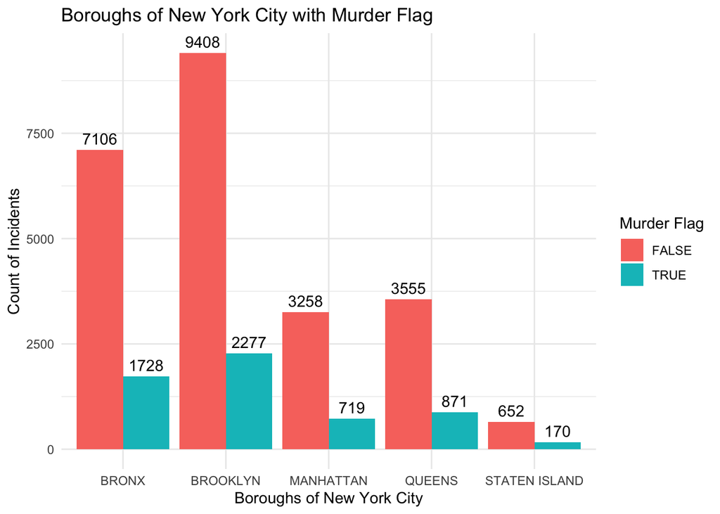

```r
# Create a summary data frame with counts
df_counts <- df_2 %>%
  group_by(BORO, STATISTICAL_MURDER_FLAG) %>%
  summarise(count = n(), .groups = 'drop')

# Create the plot
g <- ggplot(df_counts, aes(x = BORO, y = count, fill = STATISTICAL_MURDER_FLAG)) +
  geom_bar(stat = "identity", position = "dodge") +
  geom_text(aes(label = count), position = position_dodge(width = 0.9), vjust = -0.5) +
  labs(title = "Boroughs of New York City with Murder Flag",
       x = "Boroughs of New York City",
       y = "Count of Incidents") +
  theme_minimal() +
  scale_fill_discrete(name = "Murder Flag")

print(g)
```

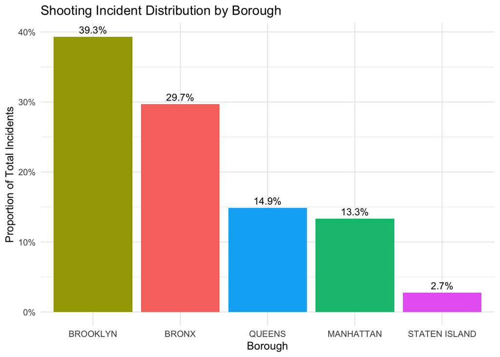

```r
# Calculate proportions
boro_counts <- df_4 %>%
  group_by(BORO) %>%
  summarise(Total = n()) %>%
  mutate(Proportion = Total / sum(Total))

# Create plot
ggplot(boro_counts, aes(x = reorder(BORO, -Proportion), y = Proportion, fill = BORO)) +
  geom_bar(stat = "identity") +
  geom_text(aes(label = scales::percent(Proportion, accuracy = 0.1)),
            vjust = -0.5, size = 3.5) +
  labs(title = "Shooting Incident Distribution by Borough",
       x = "Borough",
       y = "Proportion of Total Incidents") +
  scale_y_continuous(labels = scales::percent) +
  theme_minimal() +
  theme(legend.position = "none")
```

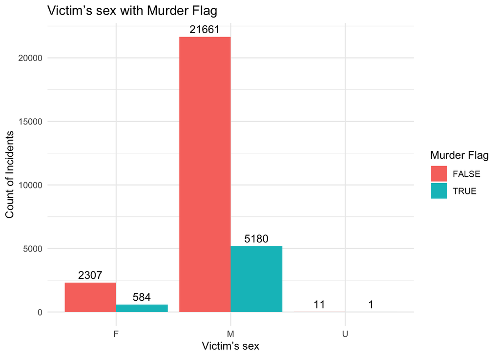

```r
# Create a summary data frame with counts
df_counts <- df_2 %>%
  group_by(VIC_SEX, STATISTICAL_MURDER_FLAG) %>%
  summarise(count = n(), .groups = 'drop')

# Create the plot
g2 <- ggplot(df_counts, aes(x = VIC_SEX, y = count, fill = STATISTICAL_MURDER_FLAG)) +
  geom_bar(stat = "identity", position = "dodge") +
  geom_text(aes(label = count), position = position_dodge(width = 0.9), vjust = -0.5) +
  labs(title = "Victim’s sex with Murder Flag",
       x = "Victim’s sex",
       y = "Count of Incidents") +
  theme_minimal() +
  scale_fill_discrete(name = "Murder Flag")

print(g2)
```

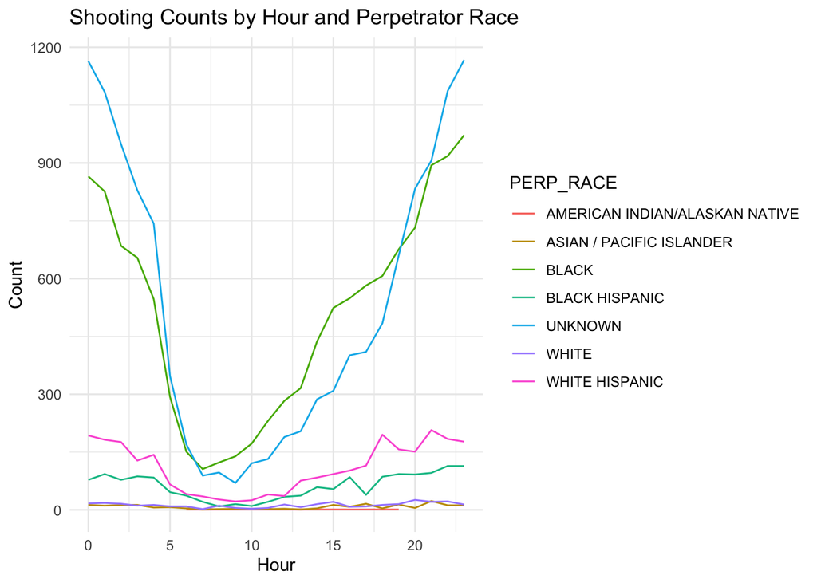

```r
# Group and summarize the data
df_counts <- df_4 %>%
  group_by(Hours, PERP_RACE) %>%
  summarise(count = n(), .groups = 'drop')

# Create the line plot
ggplot(df_counts, aes(x = Hours, y = count, color = PERP_RACE)) +
  geom_line() +
  labs(title = "Shooting Counts by Hour and Perpetrator Race",
       x = "Hour",
       y = "Count") +
  theme_minimal()
```

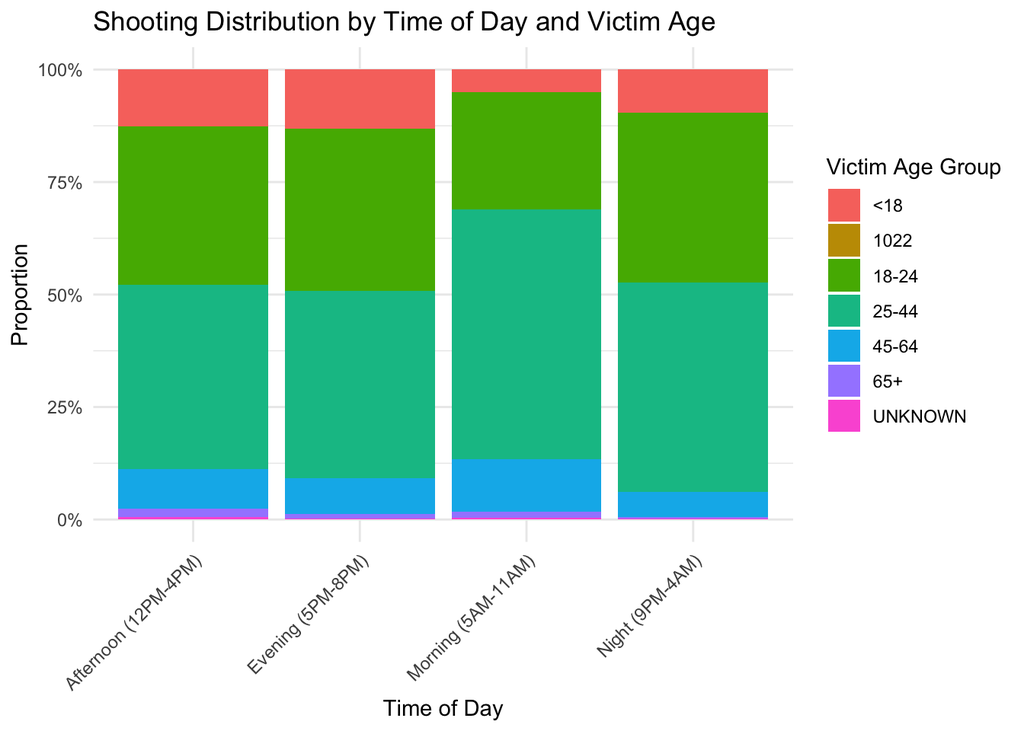

```r
# Create time categories
df_4 <- df_4 %>%
  mutate(Time_Category = case_when(
    Hours >= 5 & Hours < 12 ~ "Morning (5AM-11AM)",
    Hours >= 12 & Hours < 17 ~ "Afternoon (12PM-4PM)",
    Hours >= 17 & Hours < 21 ~ "Evening (5PM-8PM)",
    TRUE ~ "Night (9PM-4AM)"
  ))

# Plot distribution
ggplot(df_4, aes(x = Time_Category, fill = VIC_AGE_GROUP)) +
  geom_bar(position = "fill") +
  labs(title = "Shooting Distribution by Time of Day and Victim Age",
       x = "Time of Day",
       y = "Proportion",
       fill = "Victim Age Group") +
  scale_y_continuous(labels = scales::percent) +
  theme_minimal() +
  theme(axis.text.x = element_text(angle = 45, hjust = 1))
```

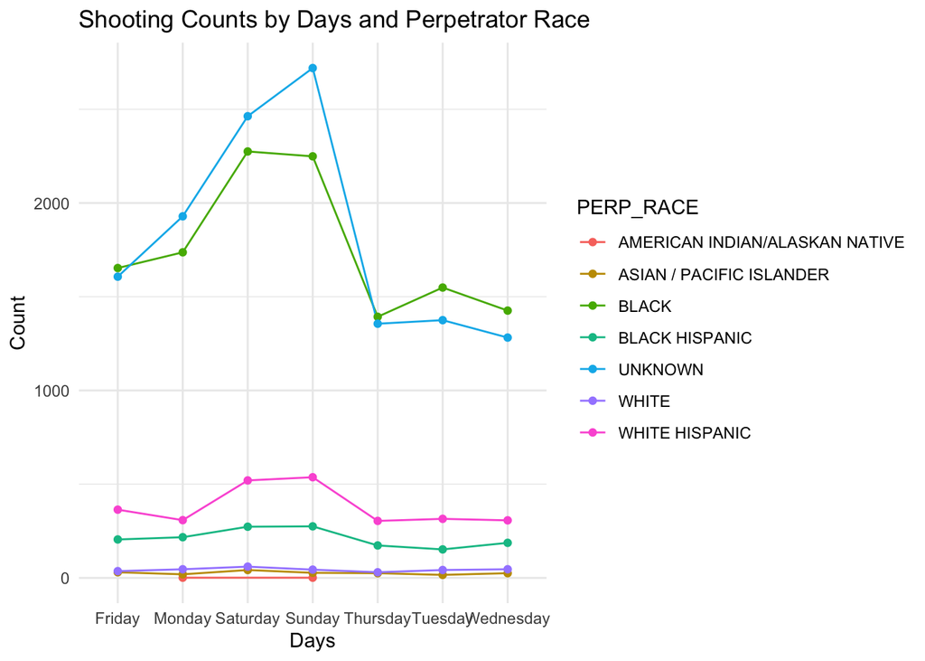

```r
df_counts <- df_4 %>%
  group_by(Days, PERP_RACE) %>%
  summarise(count = n(), .groups = 'drop')

ggplot(df_counts, aes(x = Days, y = count, color = PERP_RACE, group = PERP_RACE)) +
  geom_line() +
  geom_point() +
  labs(title = "Shooting Counts by Days and Perpetrator Race",
       x = "Days",
       y = "Count") +
  theme_minimal()
```

```r
# Prepare data for modeling
model_data <- df_4 %>%
  mutate(Murder_Flag = as.factor(ifelse(STATISTICAL_MURDER_FLAG == "TRUE", 1, 0)),
         VIC_AGE_GROUP = relevel(factor(VIC_AGE_GROUP), ref = "25-44"),
         PERP_AGE_GROUP = relevel(factor(PERP_AGE_GROUP), ref = "25-44"),
         Time_Category = relevel(factor(Time_Category), ref = "Afternoon (12PM-4PM)")) %>%
  select(Murder_Flag, VIC_AGE_GROUP, PERP_AGE_GROUP, BORO, Time_Category)

# Build model
murder_model <- glm(Murder_Flag ~ ., data = model_data, family = "binomial")

# Model summary
summary(murder_model)
```

```
##
## Call:
## glm(formula = Murder_Flag ~ ., family = "binomial", data = model_data)
##
## Coefficients:
##                                  Estimate Std. Error z value Pr(>|z|)
## (Intercept)                     -1.010580   0.053268 -18.972  < 2e-16 ***
## VIC_AGE_GROUP<18                -0.543852   0.059087  -9.204  < 2e-16 ***
## VIC_AGE_GROUP1022               -8.214810  72.462883  -0.113 0.909741
## VIC_AGE_GROUP18-24              -0.278753   0.034244  -8.140 3.94e-16 ***
## VIC_AGE_GROUP45-64               0.099982   0.055640   1.797 0.072345 .
## VIC_AGE_GROUP65+                 0.353344   0.146388   2.414 0.015790 *
## VIC_AGE_GROUPUNKNOWN            -0.245992   0.294976  -0.834 0.404315
## PERP_AGE_GROUP<18               -0.286365   0.069336  -4.130 3.63e-05 ***
## PERP_AGE_GROUP18-24             -0.203837   0.042363  -4.812 1.50e-06 ***
## PERP_AGE_GROUP45-64              0.293814   0.081985   3.584 0.000339 ***
## PERP_AGE_GROUP65+                0.350952   0.255571   1.373 0.169688
## PERP_AGE_GROUPUNKNOWN           -0.707461   0.037978 -18.628  < 2e-16 ***
## BOROBROOKLYN                     0.039466   0.036234   1.089 0.276063
## BOROMANHATTAN                   -0.136731   0.049905  -2.740 0.006147 **
## BOROQUEENS                       0.002402   0.047086   0.051 0.959315
## BOROSTATEN ISLAND               -0.049856   0.091783  -0.543 0.587000
## Time_CategoryEvening (5PM-8PM)   0.094359   0.051441   1.834 0.066609 .
## Time_CategoryMorning (5AM-11AM)  0.275371   0.060295   4.567 4.95e-06 ***
## Time_CategoryNight (9PM-4AM)     0.062911   0.044842   1.403 0.160627
## ---
## Signif. codes:  0 '***' 0.001 '**' 0.01 '*' 0.05 '.' 0.1 ' ' 1
##
## (Dispersion parameter for binomial family taken to be 1)
##
##     Null deviance: 29181  on 29640  degrees of freedom
## Residual deviance: 28427  on 29622  degrees of freedom
## AIC: 28465
##
## Number of Fisher Scoring iterations: 8
```

```r
# Calculate odds ratios
odds_ratios <- exp(coef(murder_model))
odds_ratios
```

```
##                     (Intercept)                VIC_AGE_GROUP<18
##                     0.364007709                     0.580507696
##               VIC_AGE_GROUP1022              VIC_AGE_GROUP18-24
##                     0.000270616                     0.756727025
##              VIC_AGE_GROUP45-64                VIC_AGE_GROUP65+
##                     1.105150552                     1.423820354
##            VIC_AGE_GROUPUNKNOWN               PERP_AGE_GROUP<18
##                     0.781928414                     0.750988736
##             PERP_AGE_GROUP18-24             PERP_AGE_GROUP45-64
##                     0.815595509                     1.341534570
##               PERP_AGE_GROUP65+           PERP_AGE_GROUPUNKNOWN
##                     1.420419402                     0.492894279
##                    BOROBROOKLYN                   BOROMANHATTAN
##                     1.040255152                     0.872204687
##                      BOROQUEENS               BOROSTATEN ISLAND
##                     1.002404932                     0.951366715
##  Time_CategoryEvening (5PM-8PM) Time_CategoryMorning (5AM-11AM)
##                     1.098954072                     1.317019802
##    Time_CategoryNight (9PM-4AM)
##                     1.064932489
```

The Predictive Model (Logistic Regression for Murder Outcome). We have the following important findings. 1. We find the Victim Age Significantly Impacts Fatality Odds, the Younger victims (0–17, 18–24) have lower odds of fatal outcomes compared to the baseline (25–44), and the Older victims (65+) have 42% higher odds of death.Middle-aged victims (45–64) show a non-significant trend toward higher fatality (*p* = 0.072). Younger victims may receive quicker medical intervention or suffer less lethal injuries. Elderly victims may have higher mortality due to reduced resilience. 2. We find the Perpetrator Age Also Influences Outcomes. Shootings involving younger perpetrators are less likely to be fatal (<18 and 18–24, both *p* < 0.001). Perpetrators aged 45–64 increase fatality odds by 34%. Interpretation: Younger perpetrators may use less lethal methods or target non-vital areas. Middle-aged offenders may employ more lethal force. 3. Geographic and Temporal Effects have big Borough Differences. Manhattan has 13% lower odds of fatal shootings vs. Bronx. Morning shootings (5AM–11AM) are 32% more deadly than afternoon incidents. Evening/night effects were not statistically significant Interpretation: Morning shootings may involve more premeditated violence (e.g., targeted attacks) and Manhattan’s lower fatality rate could reflect better emergency response or different crime patterns. This analysis provides a foundation for targeted interventions, such as: 1. Enhanced trauma care in high-risk boroughs (Bronx, Brooklyn).2. Focused policing during morning hours.3. Community programs for middle-aged perpetrators

## Bias Identification

A causation fallacy risk exists when interpreting borough-level correlations, as factors like poverty rates in the Bronx may confound the relationship between location and shooting outcomes. Similarly, time-of-day effects may be influenced by varying activity patterns rather than inherent differences in incident severity. Finally, age grouping bias obscures distinctions within the “18–24” category, which combines teenagers and young adults.